# Problem Set 05

WRITE YOUR NAME HERE

Due Friday, October 21, 2016

```r
library(ggplot2)
library(dplyr)
library(knitr)

# Packages containing data sets for today
library(okcupiddata)
library(gapminder)
```

## Question 1: Drug Use Amongst OkCupid Users

Let’s revisit the 60,000 San Francisco OkCupid users in 2012 and consider the variable `drug` reflecting users’ answers to a question on their drug use.

```r
data(profiles)
# Convert as missing values in drugs to an actual category "N/A"
profiles <- profiles %>%
  mutate(drugs=ifelse(is.na(drugs), "N/A", drugs))
```

#### a)

Type in a series of commands that will output how many men and women there in this population.

**Solution:** This population skews male.

```r
# Write your code below:
male_vs_female <- profiles %>%
  group_by(sex) %>%
  summarise(count=n())
kable(male_vs_female)
```

| sex | count |
| --- | --- |
| f | 24117 |
| m | 35829 |

#### b)

Create a visualization that shows the distribution of the different responses of in variable `drugs`.

**Solution:**

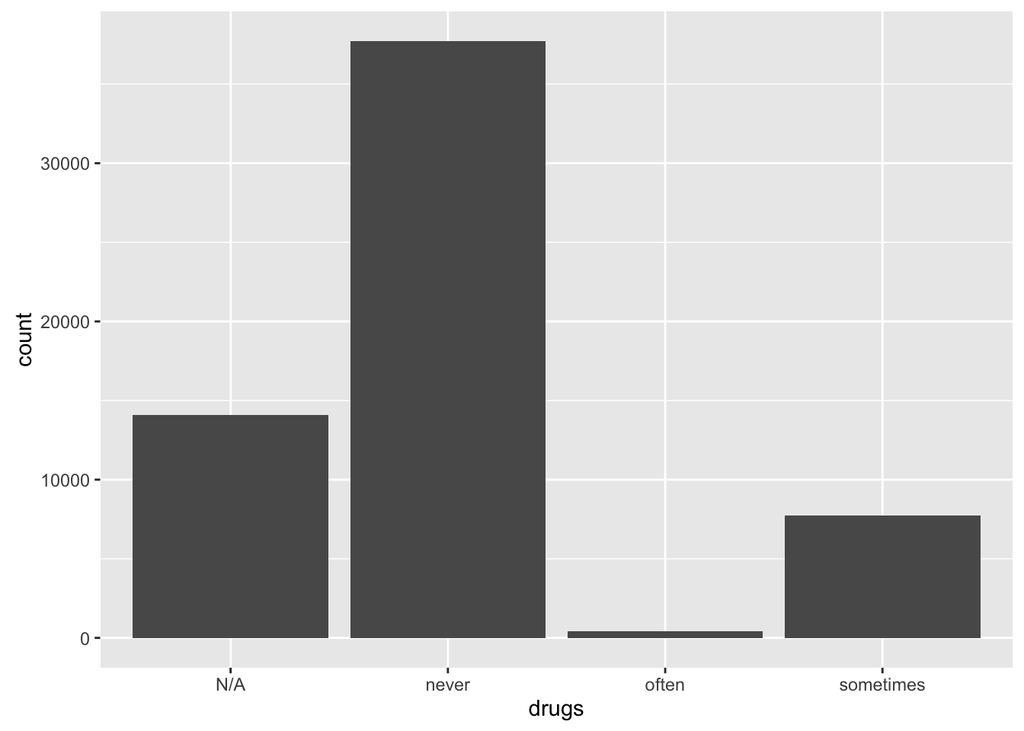

```r
ggplot(data=profiles, aes(x=drugs)) +
  geom_bar()
```

#### c)

Create a visualization that shows the same information as in part a), but for men and women separately. Who is more likely to never use drugs? Men or women?

**Solution:** We plot the raw counts of drug use split by sex. However, we can’t compare these values directly because the population involves 35,829 males and 24,117 females as we saw above!

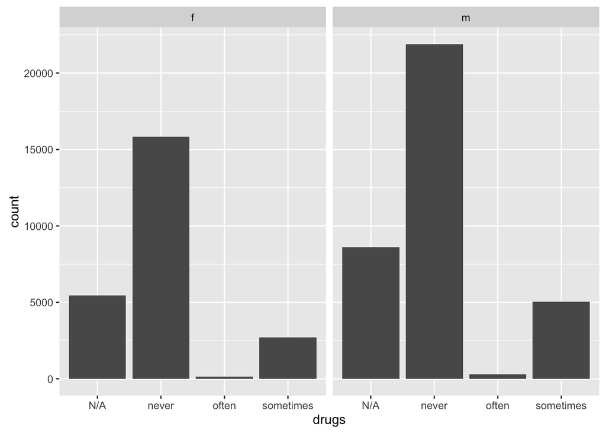

```r
ggplot(data=profiles, aes(x=drugs)) +
  geom_bar() +
  facet_wrap(~sex)
```

**Advanced**: So instead we must normalize to proportions. Note this was not expected of you for this problem set at the time, but we are now in a position to understand it. Here we `group_by` both `sex` and `drugs`, get counts, and compute proportions, we change the `group_by()` structure, and then instead of summarizing, we mutate to compute a proportion. Ask yourself, what values sum to 1?

```r
proportions <- profiles %>%
  group_by(sex, drugs) %>%
  summarise(count = n()) %>%
  group_by(sex) %>%
  mutate(proportion = count/sum(count)) %>%
  mutate(proportion = round(proportion, 2))
kable(proportions)
```

| sex | drugs | count | proportion |
| --- | --- | --- | --- |
| f | N/A | 5465 | 0.23 |
| f | never | 15829 | 0.66 |
| f | often | 128 | 0.01 |
| f | sometimes | 2695 | 0.11 |
| m | N/A | 8615 | 0.24 |
| m | never | 21895 | 0.61 |
| m | often | 282 | 0.01 |
| m | sometimes | 5037 | 0.14 |

Now let’s try to plot it. Recall from the [Lec12 Slides](https://rudeboybert.github.io/MATH116/assets/2-Data/barplots.html#8) there are two cases of barplots:

1. Where the counts are not pre-computed. what we’ve been using
2. Where the counts are pre-computed. This case.

We map the `proportion` to the `y` aesthetic. But for this to work, we need to add a note to `geom_bar()` that we are specifying a `y` aesthetic by setting `geom_bar(stat="identity")`

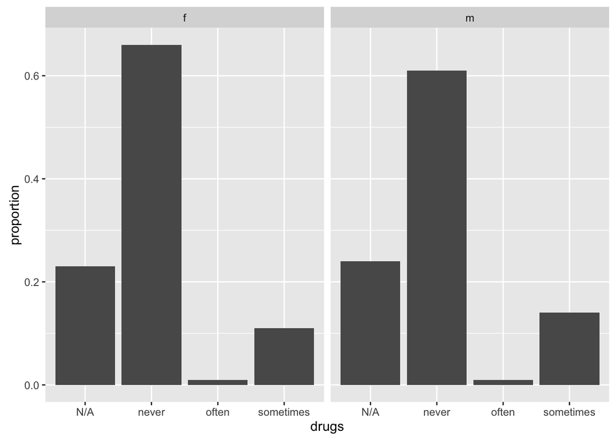

```r
ggplot(data=proportions, aes(x=drugs, y=proportion)) +
  geom_bar(stat="identity") +
  facet_wrap(~sex)
```

We now see that it is women who are more likely to self report that they never use drugs.

#### d)

In lines 54-55 above we made sure to convert all missing values, encoded in R as `NA`, to a specific response `N/A` i.e. not answered. Why do you think it was important to do so?

**Solution:** Given the nature of the variable, some people might not be willing to answer. It is important not to ignore these people or we might **bias** the results.

## Question 2: Gapminder

#### a)

Output a table that shows the mean and median GDP of all countries in the year 2007, but split by continent. Your table should be 5 rows and 3 columns

```r
data(gapminder)

mean_median_GDP_by_continent <- gapminder %>%
  filter(year==2007) %>%
  select(continent, gdpPercap) %>%
  group_by(continent) %>%
  summarise(mean_GDP_per_capita = mean(gdpPercap), median_GDP_per_capita = median(gdpPercap))
kable(mean_median_GDP_by_continent)
```

| continent | mean_GDP_per_capita | median_GDP_per_capita |
| --- | --- | --- |
| Africa | 3089.033 | 1452.267 |
| Americas | 11003.032 | 8948.103 |
| Asia | 12473.027 | 4471.062 |
| Europe | 25054.482 | 28054.066 |
| Oceania | 29810.188 | 29810.188 |

## Question 3: Titanic

```r
data(Titanic)
# Convert the Titanic data to data frame format
Titanic <- Titanic %>%
  as.data.frame()
```

#### a)

Output tables that compares survivor counts

1. between men and women
2. betweent the different classes

**Solution:** Let’s first look at the `Titanic` data

```r
kable(Titanic)
```

| Class | Sex | Age | Survived | Freq |
| --- | --- | --- | --- | --- |
| 1st | Male | Child | No | 0 |
| 2nd | Male | Child | No | 0 |
| 3rd | Male | Child | No | 35 |
| Crew | Male | Child | No | 0 |
| 1st | Female | Child | No | 0 |
| 2nd | Female | Child | No | 0 |
| 3rd | Female | Child | No | 17 |
| Crew | Female | Child | No | 0 |
| 1st | Male | Adult | No | 118 |
| 2nd | Male | Adult | No | 154 |
| 3rd | Male | Adult | No | 387 |
| Crew | Male | Adult | No | 670 |
| 1st | Female | Adult | No | 4 |
| 2nd | Female | Adult | No | 13 |
| 3rd | Female | Adult | No | 89 |
| Crew | Female | Adult | No | 3 |
| 1st | Male | Child | Yes | 5 |
| 2nd | Male | Child | Yes | 11 |
| 3rd | Male | Child | Yes | 13 |
| Crew | Male | Child | Yes | 0 |
| 1st | Female | Child | Yes | 1 |
| 2nd | Female | Child | Yes | 13 |
| 3rd | Female | Child | Yes | 14 |
| Crew | Female | Child | Yes | 0 |
| 1st | Male | Adult | Yes | 57 |
| 2nd | Male | Adult | Yes | 14 |
| 3rd | Male | Adult | Yes | 75 |
| Crew | Male | Adult | Yes | 192 |
| 1st | Female | Adult | Yes | 140 |
| 2nd | Female | Adult | Yes | 80 |
| 3rd | Female | Adult | Yes | 76 |
| Crew | Female | Adult | Yes | 20 |

We see that the variable `Freq` reports the **pre-computed** count of passengers for each `Class`, `Sex`, `Age`, `Survived` category. The key difficulty of this question was distiguising between using `n()` to count observations vs `sum()`. Here, we need to `sum(Freq)`:

```r
survival_by_sex <- Titanic %>%
  group_by(Sex, Survived) %>%
  summarise(Freq=sum(Freq))
kable(survival_by_sex)
```

| Sex | Survived | Freq |
| --- | --- | --- |
| Male | No | 1364 |
| Male | Yes | 367 |
| Female | No | 126 |
| Female | Yes | 344 |

```r
survival_by_class <- Titanic %>%
  group_by(Class, Survived) %>%
  summarise(Freq=sum(Freq))
kable(survival_by_class)
```

| Class | Survived | Freq |
| --- | --- | --- |
| 1st | No | 122 |
| 1st | Yes | 203 |
| 2nd | No | 167 |
| 2nd | Yes | 118 |
| 3rd | No | 528 |
| 3rd | Yes | 178 |
| Crew | No | 673 |
| Crew | Yes | 212 |

#### b)

For each comparison above, indicate who was most likely to survive.

**Advanced**: convert to proportions

```r
survival_by_class_prop <- Titanic %>%
  group_by(Class, Survived) %>%
  summarise(Freq=sum(Freq)) %>%
  group_by(Class) %>%
  mutate(proportion = Freq/sum(Freq)) %>%
  mutate(proportion = round(proportion, 3))
kable(survival_by_class_prop)
```

| Class | Survived | Freq | proportion |
| --- | --- | --- | --- |
| 1st | No | 122 | 0.375 |
| 1st | Yes | 203 | 0.625 |
| 2nd | No | 167 | 0.586 |
| 2nd | Yes | 118 | 0.414 |
| 3rd | No | 528 | 0.748 |
| 3rd | Yes | 178 | 0.252 |
| Crew | No | 673 | 0.760 |
| Crew | Yes | 212 | 0.240 |